# Regresión logística

Supongamos que tenemos un conjunto de datos $D = \{\mathbf{e}_{1}, \dotsc, \mathbf{e}_{m}\}$, donde cada ejemplo $\mathbf{e}_{j}$ es un vector de la forma
$$\begin{equation*}
\mathbf{e}_{j} = (x_{1 j}, \dotsc, x_{n j}, y_j)^{T}
\end{equation*}$$
siendo $x_{i j}$ números reales e $y_{j}$ un valor binario ($0$ o $1$).

Un modelo de regresión logística asume $X_1, \dotsc, X_n$ como variables predictoras e $Y$ como variable respuesta, y considera que
$$\begin{align*}
p
&= \mathbb{P}(Y = 1 \mid X_{1}, \dotsc, X_{n})
= \frac{
\mathrm{e}^{\beta_{0} + \beta_{1} X_1 + \dotsb + \beta_{n} X_n}
}{
1 + \mathrm{e}^{\beta_{0} + \beta_{1} X_1 + \dotsb + \beta_{n}
X_n}
} \\
q
&= \mathbb{P}(Y = 0 \mid X_{1}, \dotsc, X_{n})
= 1 - p
\end{align*}$$
donde $\beta_{0}, \dotsc, \beta_{n}$ son los parámetros del modelo (nótese que $0 < p, q < 1$ para cualesquiera valores de estos parámetros).

Usando notación matricial, si denotamos $\boldsymbol{\beta} = (\beta_{0}, \dotsc, \beta_{n})^{T}$ y $\mathbf{X} = (1, X_{1}, \dotsc, X_{n})^{T}$, entonces
$$\begin{align*}
p
&= \frac{
\mathrm{e}^{\boldsymbol{\beta}^{T} \mathbf{X}}
}{
1 + \mathrm{e}^{\boldsymbol{\beta}^{T} \mathbf{X}}
}
= \frac{
1
}{
1 + \mathrm{e}^{-\boldsymbol{\beta}^{T} \mathbf{X}}
} \\
q
&= \frac{
1
}{
1 + \mathrm{e}^{\boldsymbol{\beta}^{T} \mathbf{X}}
}
= \frac{
\mathrm{e}^{-\boldsymbol{\beta}^{T} \mathbf{X}}
}{
1 + \mathrm{e}^{-\boldsymbol{\beta}^{T} \mathbf{X}}
}
\end{align*}$$

El conjunto de datos `logit` del paquete `mcmc` contiene cien ejemplos con los valores de cuatro variables predictoras y de la variable respuesta.

```r
data(logit, package = "mcmc")

head(logit)
```

```
##   y     x1     x2     x3     x4
## 1 0 -0.162 -0.348 -0.524 -0.312
## 2 1  0.187 -0.410  0.362 -0.366
## 3 1  0.160  1.649 -0.664  0.051
## 4 1  1.536  0.084  0.403  1.732
## 5 1 -0.162 -0.061  0.192  0.256
## 6 0 -2.855 -3.341 -2.549 -1.461
```

Se pretende realizar una estimación bayesiana de los parámetros del modelo de regresión logística correspondiente. Para ello,

1. Consideramos como distribución a priori de los parámetros una distribución normal: $\beta_{i} \sim \mathrm{N}(0, 4), i = 0, \dotsc, 4$. Por tanto,
   $$\begin{equation*}
   f_{\mathrm{pri}}(\boldsymbol{\beta}) \propto
   \prod_{i = 0}^{4} \mathrm{e}^{-\frac{\beta_{i}^{2}}{8}}
   \end{equation*}$$
2. Asumiendo como independientes los ejemplos del conjunto de datos $D$, se tiene para este último la siguiente verosimilitud:
   $$\begin{equation*}
   \mathbb{P}(D \mid \boldsymbol{\beta})
   = \prod_{j = 1}^{100} \mathbb{P}(\mathbf{e}_{j} \mid
   \boldsymbol{\beta})
   = \prod_{\substack{j = 1\\y_{j} = 1}}^{100} p_{j}
   \prod_{\substack{j = 1\\y_{j} = 0}}^{100} q_{j}
   = \prod_{j = 1}^{100} p_{j}^{y_{j}} q_{j}^{1 - y_{j}}
   \end{equation*}$$
   donde $\mathbf{e}_{j} = (x_{1 j}, \dotsc, x_{4 j}, y_j)^{T}, p_{j} = \mathbb{P}(y_{j} = 1 \mid x_{1 j}, \dotsc, x_{4 j})$ y $q_{j} = \mathbb{P}(y_{j} = 0 \mid x_{1 j}, \dotsc, x_{4 j})$.
3. En consecuencia, usando la regla de Bayes la distribución a posteriori de los parámetros viene dada por
   $$\begin{equation*}
   f_{\mathrm{pos}}(\boldsymbol{\beta} \mid D)
   \propto \prod_{j = 1}^{100} p_{j}^{y_{j}} q_{j}^{1 - y_{j}}
   \prod_{i = 0}^{4} \mathrm{e}^{-\frac{\beta_{i}^{2}}{8}}
   \end{equation*}$$

Usaremos, por tanto, el método de Montecarlo por cadenas de Markov para estimar $\mathbb{E}_{f_{\mathrm{pos}}}[\boldsymbol{\beta}]$. En concreto, vamos a realizar un paseo aleatorio de Metropolis usando la función `metrop` del paquete `mcmc`. Esta función requiere que le pasemos el logaritmo de la densidad objetivo, que en nuestro caso toma la forma
$$\begin{equation*}
\log f_{\mathrm{pos}}(\boldsymbol{\beta} \mid D)
\propto \sum_{j = 1}^{100} \bigl( y_{j} \log p_{j} + (1 - y_{j}) \log
q_{j} \bigr) -
\frac{1}{8} \sum_{i = 0}^{4} \beta_{i}^{2}
\end{equation*}$$
donde
$$\begin{align*}
\log p_{j}
&= \boldsymbol{\beta}^{T} \mathbf{x}_{j} - \log(1 +
\mathrm{e}^{\boldsymbol{\beta}^{T} \mathbf{x}_{j}})
= - \log(1 + \mathrm{e}^{-\boldsymbol{\beta}^{T} \mathbf{x}_{j}}) \\
\log q_{j}
&= - \log(1 + \mathrm{e}^{\boldsymbol{\beta}^{T} \mathbf{x}_{j}})
= - \boldsymbol{\beta}^{T} \mathbf{x}_{j} - \log(1 +
\mathrm{e}^{-\boldsymbol{\beta}^{T} \mathbf{x}_{j}})
\end{align*}$$

Teniendo en cuenta esto último, al realizar operaciones numéricas en el ordenador podemos encontrarnos dos tipos de problemas:

- En primer lugar, si el exponente de la función $\mathrm{e}^{x}$ es excesivamente grande, el resultado será demasiado grande para poder representarse en el ordenador y se obtendría `Inf` en su lugar.

  ```r
  exp(709)
  ```

  ```
  ## [1] 8.218407e+307
  ```

  ```r
  exp(710)
  ```

  ```
  ## [1] Inf
  ```

  Para evitar este problema, siempre calcularemos $\log p_{j}$ y $\log q_{j}$ usando la versión en la que el exponente es negativo.
- En segundo lugar, para calcular $log(1 + x)$ cuando $|x|$ es muy cercano a cero es conveniente usar la función `log1p`.

  ```r
  log(1 + 1e-16)
  ```

  ```
  ## [1] 0
  ```

  ```r
  log1p(1e-16)
  ```

  ```
  ## [1] 1e-16
  ```

Para facilitar la definición del logaritmo de la función de densidad a posteriori no normalizada es conveniente separar del conjunto de datos los valores de la variable respuesta y construir la matriz $\mathbf{X}$ de valores de las variables predictoras y aumentada con una columna de unos.

```r
y <- logit$y
head(y)
```

```
## [1] 0 1 1 1 1 0
```

```r
x <- cbind(1, as.matrix(logit[-1]))
head(x)
```

```
##            x1     x2     x3     x4
## [1,] 1 -0.162 -0.348 -0.524 -0.312
## [2,] 1  0.187 -0.410  0.362 -0.366
## [3,] 1  0.160  1.649 -0.664  0.051
## [4,] 1  1.536  0.084  0.403  1.732
## [5,] 1 -0.162 -0.061  0.192  0.256
## [6,] 1 -2.855 -3.341 -2.549 -1.461
```

```r
logposteriori <- function(betas) {
  z <- as.vector(betas %*% t(x))
  logp <- ifelse(z < 0,
    z - log1p(exp(z)),
    -log1p(exp(-z))
  )
  logq <- ifelse(z < 0,
    -log1p(exp(z)),
    -z - log1p(exp(-z))
  )
  logverosimilitud <- sum(y * logp + (1 - y) * logq)
  logpriori <- -sum(betas^2) / 8
  logverosimilitud + logpriori
}
```

Como valores iniciales para los parámetros de la regresión logística tomamos los más probables a priori, $\beta_{i} = 0$ para $i = 0, \dotsc, 4$, queriendo esto decir que inicialmente consideramos $p_{j} = q_{j} = \tfrac{1}{2}$. Aunque más adelante veremos que la cadena de Markov converge rápidamente a partir de estos valores iniciales, en realidad los parámetros más probables a priori no tendrían por qué ser también probables a posteriori. Una manera más rigurosa de obtener buenos valores iniciales sería a partir de los coeficientes de un modelo lineal generalizado ajustado al conjunto de datos.

A continuación, buscamos, según la regla empírica, que el porcentaje de estados aceptados al generar la realización del paseo aleatorio de Metropolis sea del 25 %. Finalmente, realizamos un diagnóstico de convergencia mediante una gráfico de traza.

```r
library(mcmc)
library(coda)

betas_iniciales <- rep(0, times = 5)
paseo_Metropolis <- metrop(logposteriori, initial = betas_iniciales, nbatch = 1e4)
paseo_Metropolis$accept
```

```
## [1] 0.0206
```

```r
paseo_Metropolis <- metrop(paseo_Metropolis, scale = .5)
paseo_Metropolis$accept
```

```
## [1] 0.1507
```

```r
paseo_Metropolis <- metrop(paseo_Metropolis, scale = .25)
paseo_Metropolis$accept
```

```
## [1] 0.4247
```

```r
paseo_Metropolis <- metrop(paseo_Metropolis, scale = .4)
paseo_Metropolis$accept
```

```
## [1] 0.2414
```

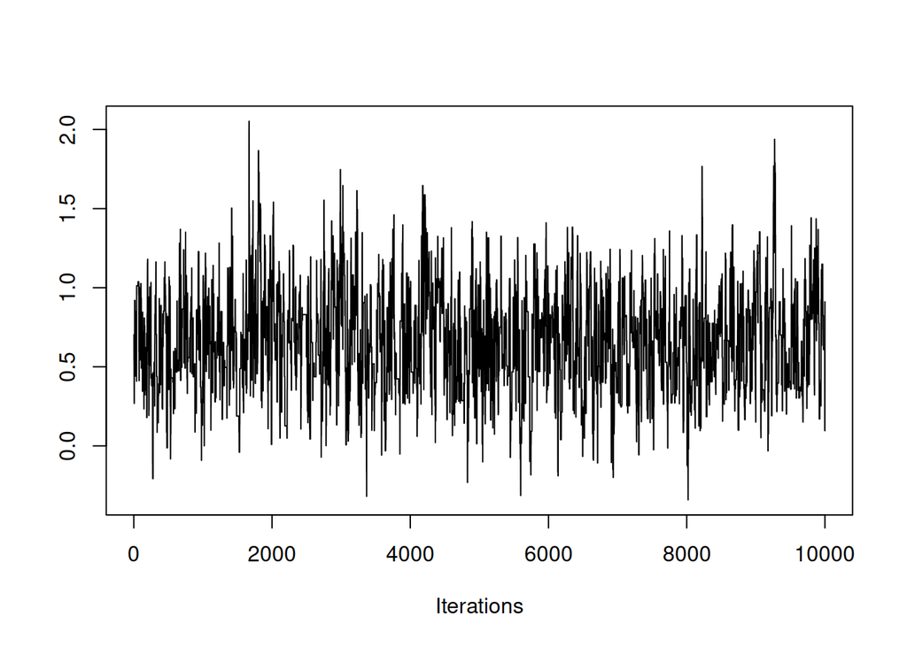

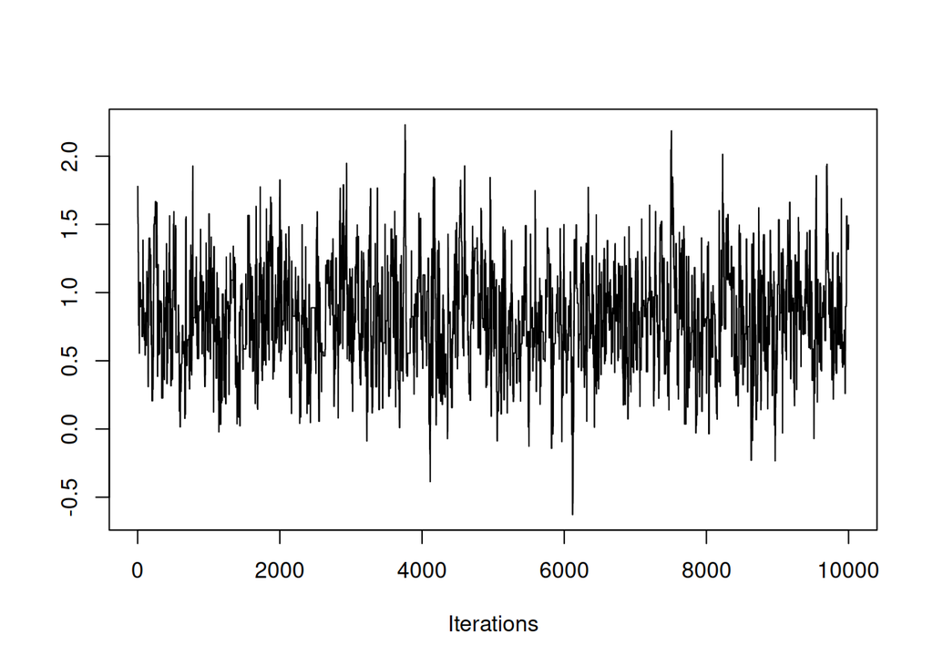

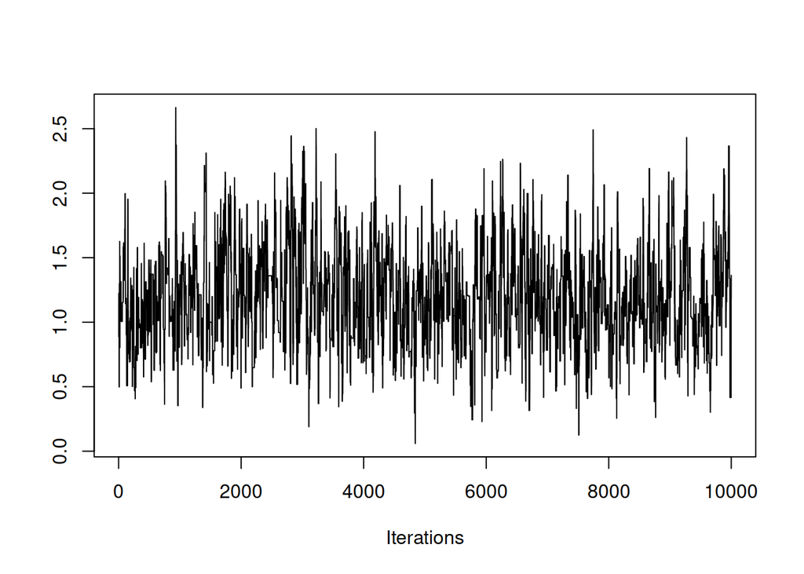

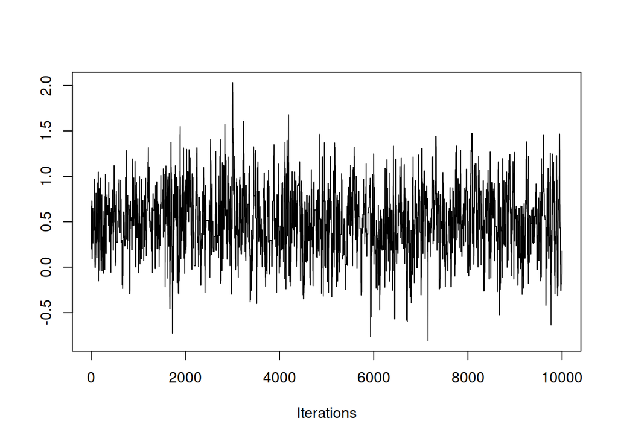

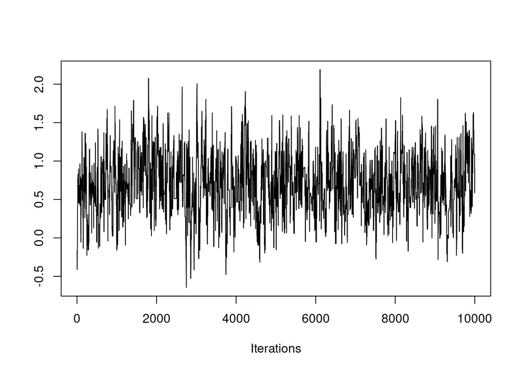

```r
paseo_Metropolis$batch |>
  mcmc() |>
  traceplot()
```

Estamos ya en condiciones de realizar la estimación requerida, construyendo un intervalo de confianza mediante el método de las medias por lotes.

El gráfico de autocorrelación muestra que una longitud $100$ para los lotes es adecuada para obtener unas medias de los lotes suficientemente independientes.

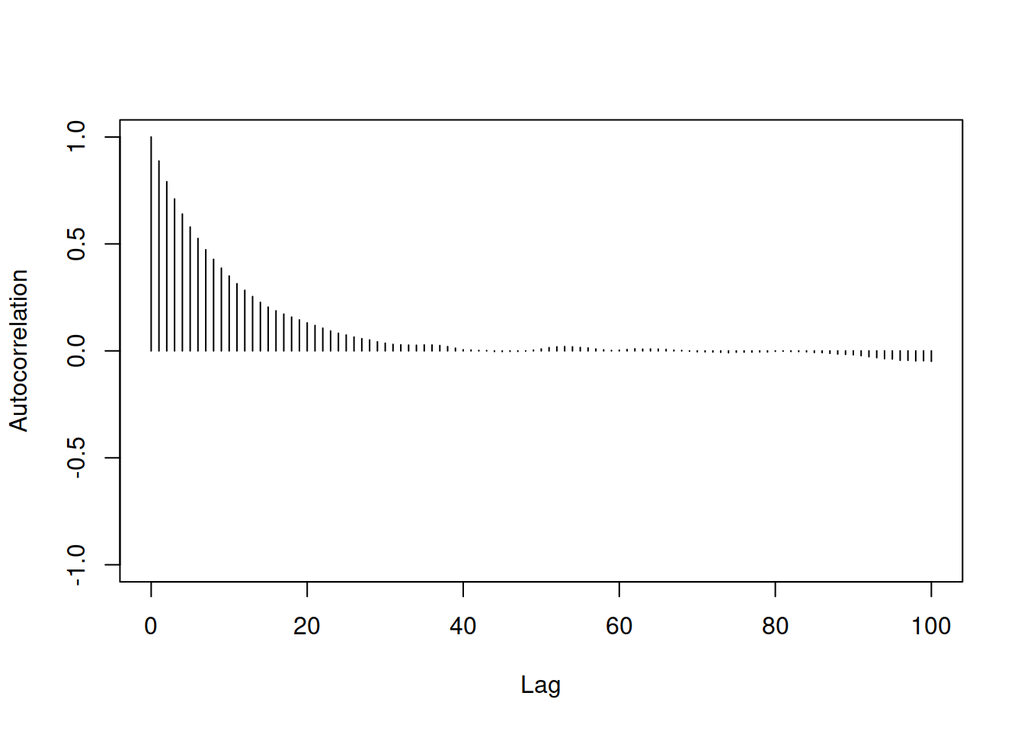

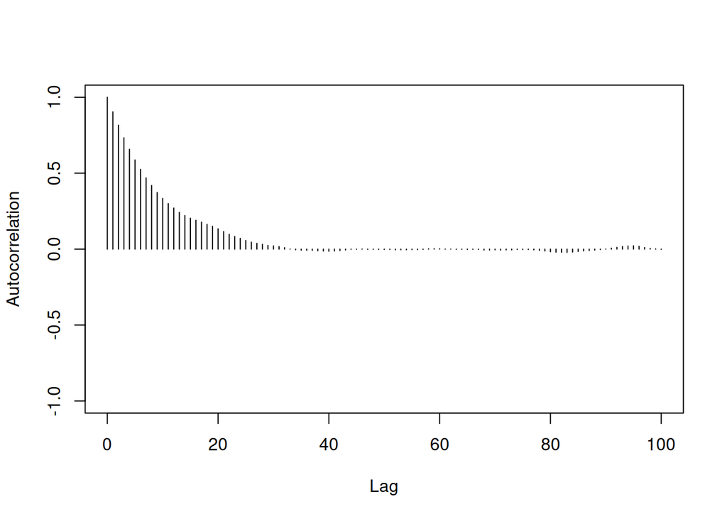

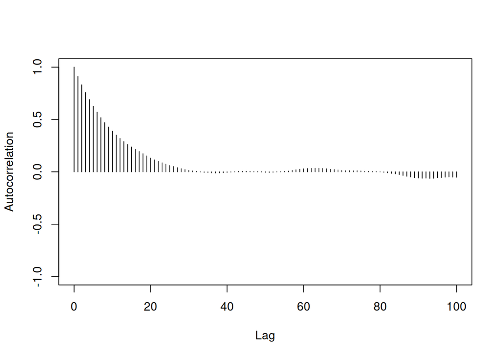

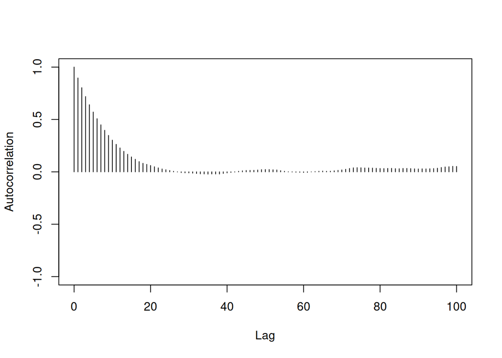

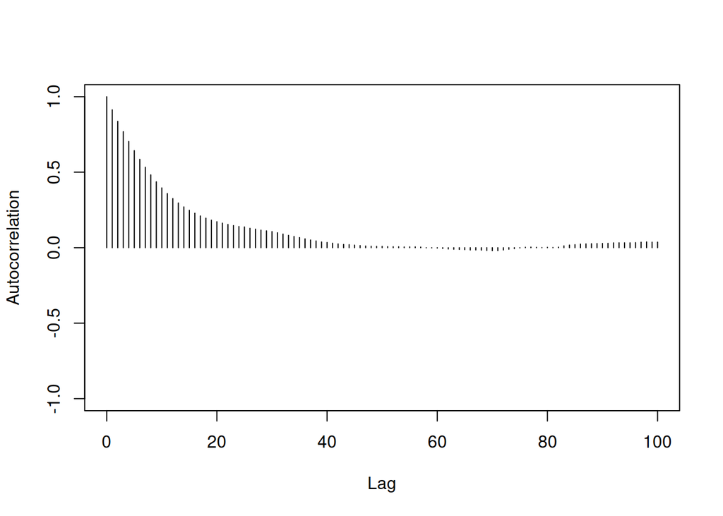

```r
paseo_Metropolis$batch |>
  mcmc() |>
  autocorr.plot(lag.max = 100, auto.layout = FALSE)
```

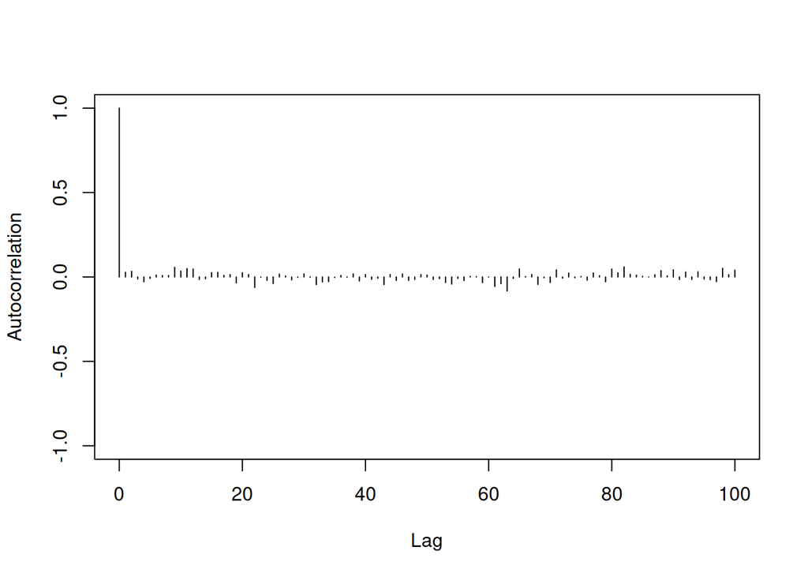

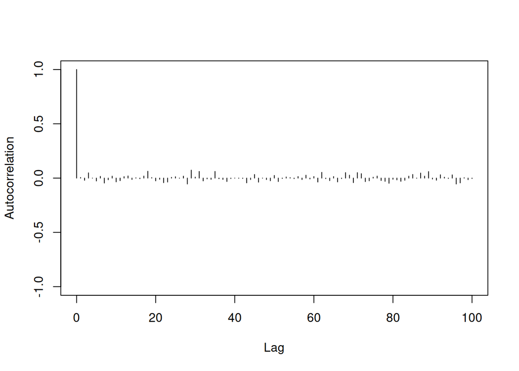

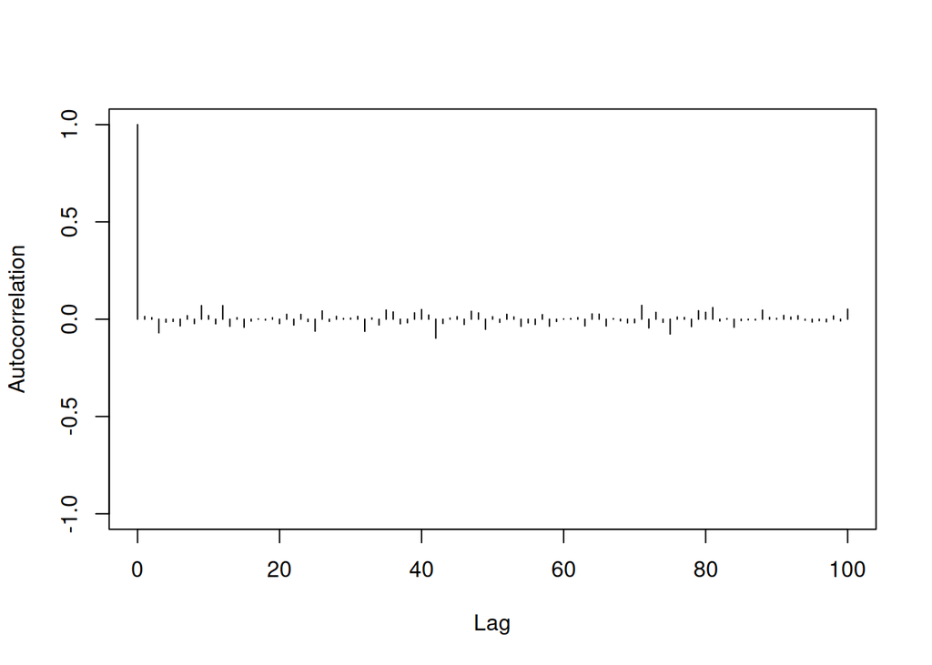

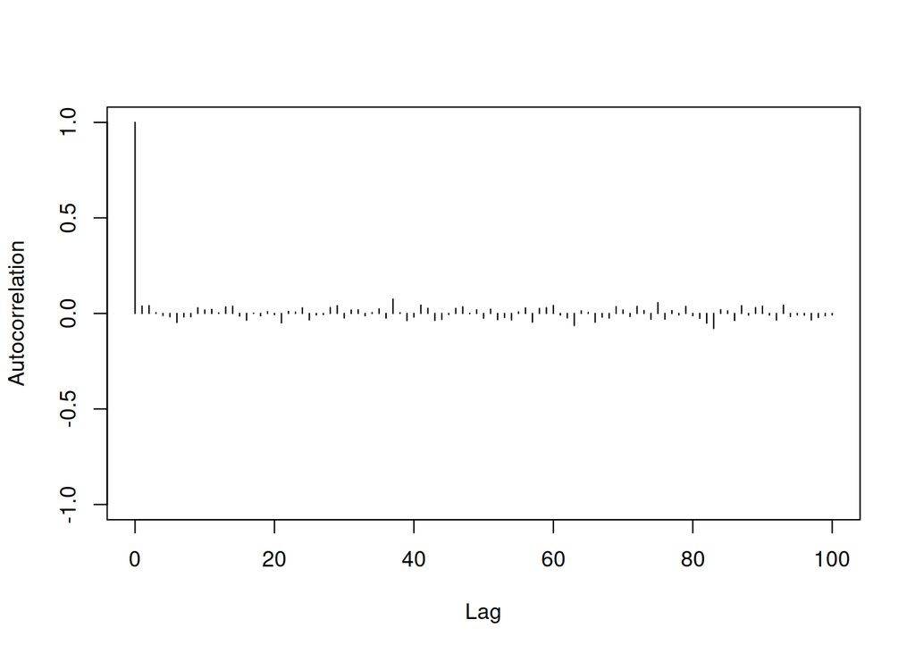

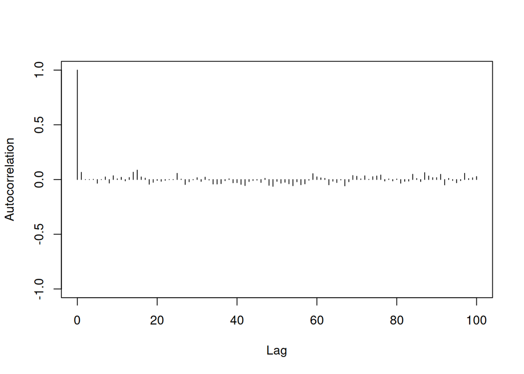

```r
paseo_Metropolis <- metrop(paseo_Metropolis, nbatch = 1e3, blen = 1e2)

paseo_Metropolis$batch |>
  mcmc() |>
  autocorr.plot(lag.max = 100, auto.layout = FALSE)
```

```r
library(purrr)

estimaciones_betas <- paseo_Metropolis$batch |>
  array_branch(margin = 2) |>
  map_dbl(mean)
names(estimaciones_betas) <- paste0("beta", 0:4)
estimaciones_betas
```

```
##     beta0     beta1     beta2     beta3     beta4
## 0.6702133 0.7911775 1.1761345 0.5049449 0.7376126
```

```r
errores_estandar_betas <- paseo_Metropolis$batch |>
  array_branch(margin = 2) |>
  map_dbl(var) |>
  magrittr::divide_by(paseo_Metropolis$nbatch) |>
  sqrt()
# También se pueden calcular como sigue:
# errores_estandar_betas <- paseo_Metropolis$batch |>
#   array_branch(margin = 2) |>
#   map_dbl(\(x) sqrt(var(x) / paseo_Metropolis$nbatch))

probabilidad_cobertura <- 0.95
alfa <- 1 - probabilidad_cobertura
percentil <- qnorm(1 - alfa / 2)
map2(
  estimaciones_betas,
  errores_estandar_betas,
  \(estimacion, error) estimacion + c(-1, 1) * error * percentil
)
```

```
## $beta0
## [1] 0.6622529 0.6781737
##
## $beta1
## [1] 0.7811434 0.8012117
##
## $beta2
## [1] 1.166302 1.185967
##
## $beta3
## [1] 0.4955594 0.5143304
##
## $beta4
## [1] 0.7260266 0.7491986
```